# Toluene Exposure and Blood Concentration

Hajin Jang

2/12/2024

### This code was written to analyze the relationship between inhaled toluene exposure and blood toluene concentration in rats using visualization, regression modeling, diagnostic assessment, and robustness checks.

```r
library(tidyverse)
library(psych)
library(car)
library(MASS)
library(dplyr)
library(skimr)
library(sfsmisc)
```

# Data Management

We will use these data to model the relationship between toluene exposure and blood concentration, adjusting for other variables.

```r
# read in data (csv file)
toluene <- read.csv("toluene.csv")
toluene = toluene %>% mutate(snoutsize_f = factor(snoutsize, levels = c(1, 2), labels = c("short", "long")))
```

# Part 1) Visualize data

**Calculating some descriptive statistics and displaying some plots to learn about the data.**

```r
# quick look at the data
skimr::skim(toluene)
```

Data summary

| Name | toluene |
| --- | --- |
| Number of rows | 60 |
| Number of columns | 7 |
| _______________________ |  |
| Column type frequency: |  |
| factor | 1 |
| numeric | 6 |
| ________________________ |  |
| Group variables | None |

**Variable type: factor**

| skim_variable | n_missing | complete_rate | ordered | n_unique | top_counts |
| --- | --- | --- | --- | --- | --- |
| snoutsize_f | 0 | 1 | FALSE | 2 | lon: 45, sho: 15 |

**Variable type: numeric**

| skim_variable | n_missing | complete_rate | mean | sd | p0 | p25 | p50 | p75 | p100 | hist |
| --- | --- | --- | --- | --- | --- | --- | --- | --- | --- | --- |
| rat | 0 | 1 | 30.50 | 17.46 | 1.00 | 15.75 | 30.50 | 45.25 | 60.00 | ▇▇▇▇▇ |
| bloodtol | 0 | 1 | 11.00 | 12.62 | 0.22 | 0.70 | 6.54 | 22.07 | 39.54 | ▇▃▁▂▂ |
| weight | 0 | 1 | 380.55 | 72.71 | 100.00 | 350.25 | 373.50 | 406.00 | 700.00 | ▁▂▇▁▁ |
| age | 0 | 1 | 83.40 | 5.70 | 70.00 | 82.25 | 85.00 | 86.00 | 95.00 | ▃▂▇▅▂ |
| newppm | 0 | 1 | 292.48 | 311.99 | 3.57 | 50.70 | 104.50 | 502.50 | 1000.00 | ▇▂▂▂▂ |
| snoutsize | 0 | 1 | 1.75 | 0.44 | 1.00 | 1.75 | 2.00 | 2.00 | 2.00 | ▂▁▁▁▇ |

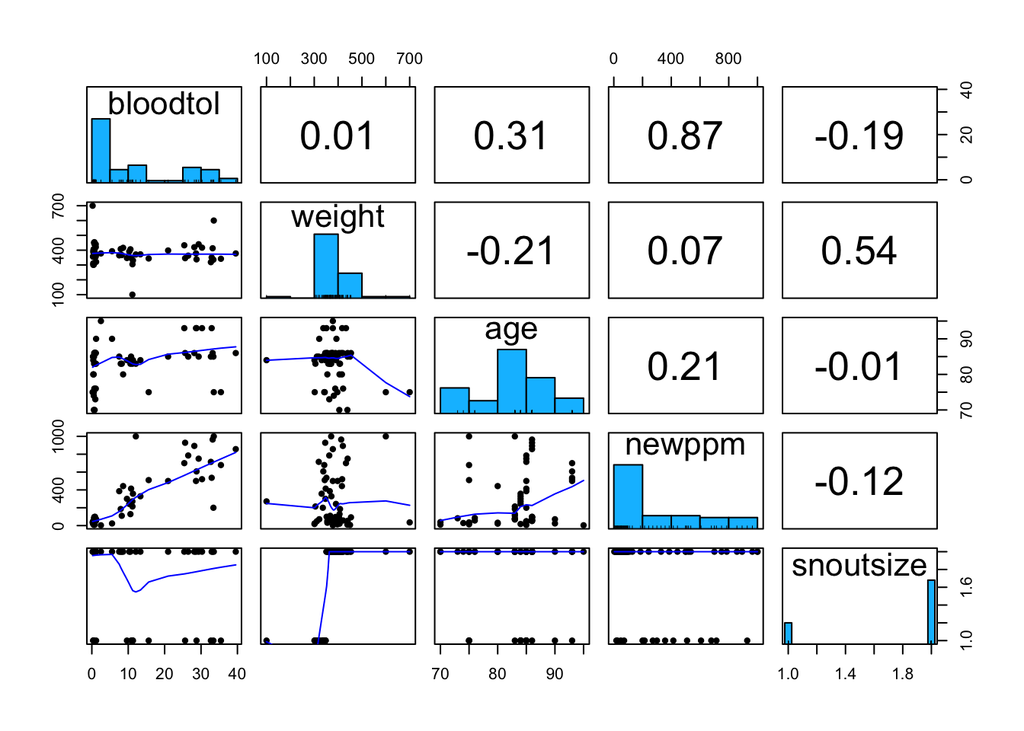

```r
# plot pairs of variables
pairs.panels(toluene[,c("bloodtol","weight","age","newppm","snoutsize")],
             ellipses = F, density = F, hist.col = "deepskyblue")
```

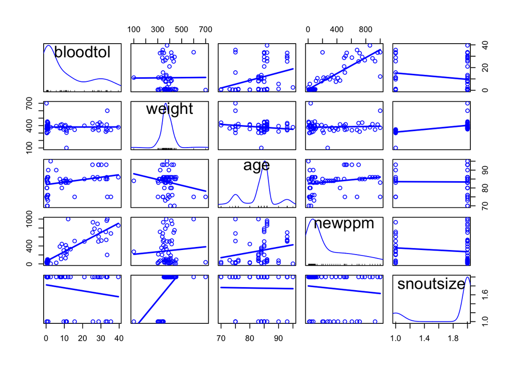

```r
# scatterplot matrix
scatterplotMatrix(~bloodtol+weight+age+newppm+snoutsize, data=toluene, smooth=F)
```

**Comment:** There are total 60 observations (rats) and 7 variables in the data. There are 1 factor and 6 numeric variables. There is no missing data in all of the variables. The mean (sd) of the variables is as follows: toluene in blood (mg/L) = 11.00 (12.62) weight (g) = 380.55 (72.71) age (days) = 83.40 (5.70) toluene exposure (ppm) = 292.48 (311.99) snout size = 45 of long snout and 15 of short snout. According to the correlation plots, toluene exposure and toluene blood seems to have strong positive correlation (r=0.87).

# Part 2) SLR

**Fitting a regression model for blood toluene (bloodtol) that contains only toluene exposure (newppm) as a predictor; performing a graphical analysis to assess the linearity, equal variance, and normality assumptions of linear regression.**

```r
# fit slr model
fit1 <- lm(bloodtol ~ newppm, data=toluene)
summary(fit1)
```

```
##
## Call:
## lm(formula = bloodtol ~ newppm, data = toluene)
##
## Residuals:
##     Min      1Q  Median      3Q     Max
## -23.688  -2.340  -1.550   1.208  25.635
##
## Coefficients:
##             Estimate Std. Error t value Pr(>|t|)
## (Intercept)  0.76422    1.13233   0.675    0.502
## newppm       0.03501    0.00266  13.163   <2e-16 ***
## ---
## Signif. codes:  0 '***' 0.001 '**' 0.01 '*' 0.05 '.' 0.1 ' ' 1
##
## Residual standard error: 6.374 on 58 degrees of freedom
## Multiple R-squared:  0.7492, Adjusted R-squared:  0.7449
## F-statistic: 173.3 on 1 and 58 DF,  p-value: < 2.2e-16
```

```r
# plot residual vs fitted and residual qq-plot
raw_resid = residuals(fit1)
head(raw_resid)
```

```
##          1          2          3          4          5          6
##  3.9485764  1.6047510 -0.4052795 -0.3763100 -0.8443406 -0.9923711
```

```r
stand_resid = rstandard(fit1)
head(stand_resid)
```

```
##           1           2           3           4           5           6
##  0.62877159  0.25580203 -0.06459083 -0.05996296 -0.13451694 -0.15807255
```

```r
jack_resid = rstudent(fit1)
head(jack_resid)
```

```
##           1           2           3           4           5           6
##  0.62546294  0.25373042 -0.06403390 -0.05944564 -0.13337307 -0.15673770
```

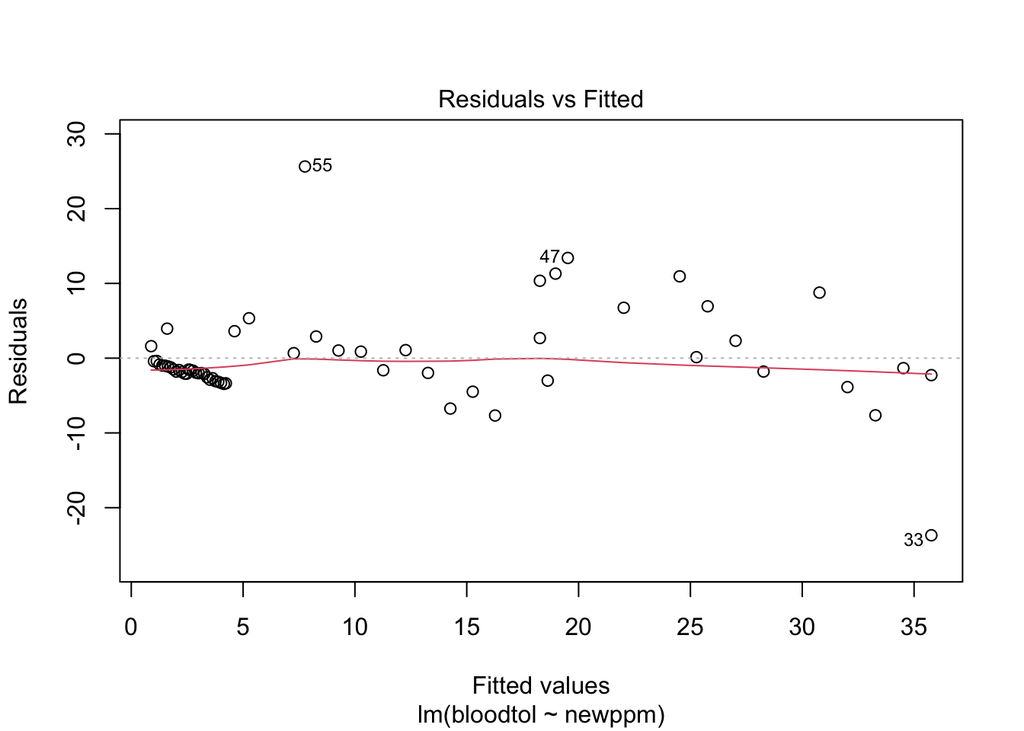

```r
# residual vs. fitted. values
resid_fitted <- plot(fit1, which=1)
```

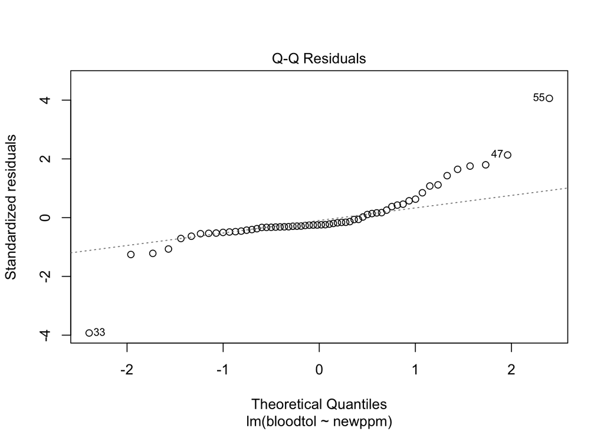

```r
# residual qq plot
resid_qq <- plot(fit1, which=2)
```

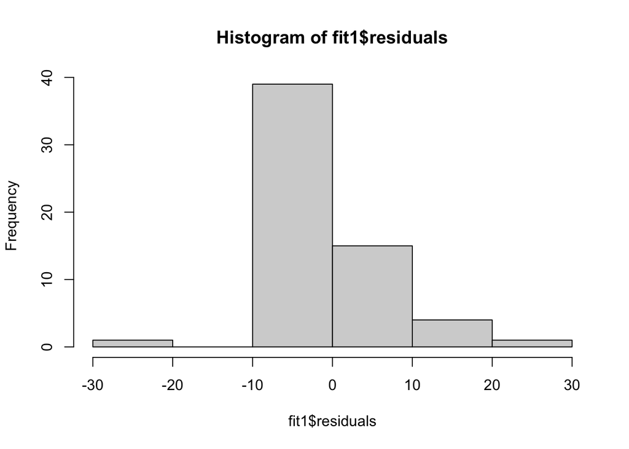

```r
# histogram of residuals
resid_hist <- hist(fit1$residuals)
```

**Interpretation:** According to the Residuals vs. Fitted plot, the linearity and equal variance assumption seemed to be fine while normality assumption was violated. The plot showed linear distribution of fitted values and residuals. There is no specific fanning/funnel shape, so the equal variance assumption is not violated. However, the qq-plot showed right-skewed distribution rather than the normal distribution.

# Part 3) MLR

**Adding covariates to the model.**

```r
fit2 <- lm(bloodtol ~ newppm + weight + age + snoutsize_f, data=toluene)
summary(fit2)
```

```
##
## Call:
## lm(formula = bloodtol ~ newppm + weight + age + snoutsize_f,
##     data = toluene)
##
## Residuals:
##      Min       1Q   Median       3Q      Max
## -21.2982  -2.5936  -0.6433   2.0629  22.7613
##
## Coefficients:
##                   Estimate Std. Error t value Pr(>|t|)
## (Intercept)     -25.190637  14.283095  -1.764   0.0833 .
## newppm            0.033114   0.002732  12.122   <2e-16 ***
## weight            0.007849   0.013948   0.563   0.5759
## age               0.312591   0.150875   2.072   0.0430 *
## snoutsize_flong  -3.397497   2.274375  -1.494   0.1409
## ---
## Signif. codes:  0 '***' 0.001 '**' 0.01 '*' 0.05 '.' 0.1 ' ' 1
##
## Residual standard error: 6.201 on 55 degrees of freedom
## Multiple R-squared:  0.7749, Adjusted R-squared:  0.7585
## F-statistic: 47.32 on 4 and 55 DF,  p-value: < 2.2e-16
```

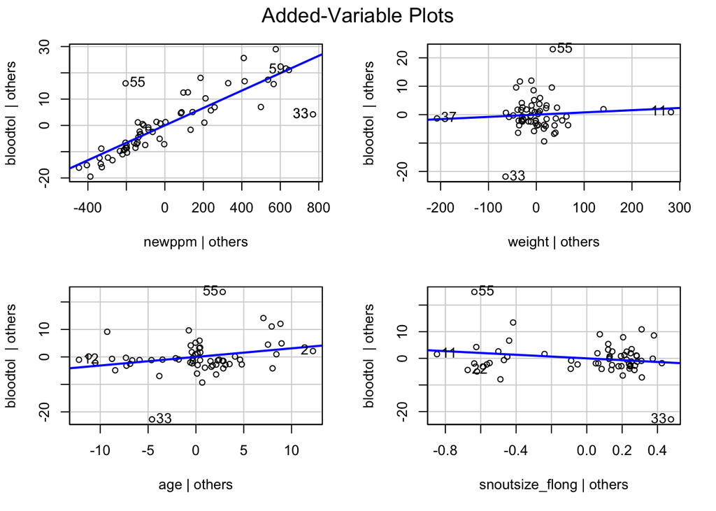

```r
avPlots(fit2)
```

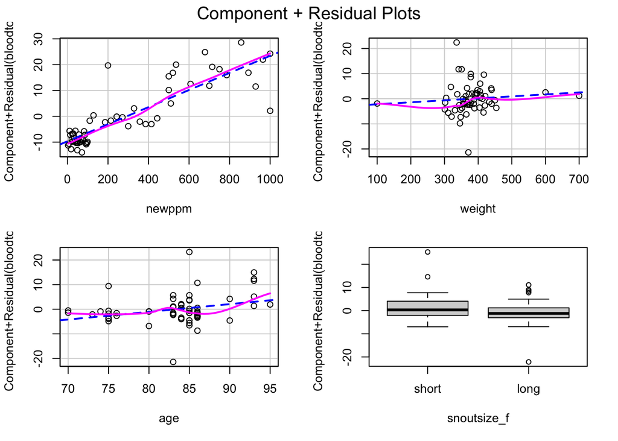

```r
crPlots(fit2)
```

```r
# model with interactions included
fit3 <- lm(bloodtol ~ newppm + weight + age + snoutsize_f + newppm*weight + newppm*age + newppm*snoutsize_f, data=toluene)
summary(fit3)
```

```
##
## Call:
## lm(formula = bloodtol ~ newppm + weight + age + snoutsize_f +
##     newppm * weight + newppm * age + newppm * snoutsize_f, data = toluene)
##
## Residuals:
##      Min       1Q   Median       3Q      Max
## -18.4224  -3.2132  -0.5186   1.6325  23.0298
##
## Coefficients:
##                          Estimate Std. Error t value Pr(>|t|)
## (Intercept)            -8.030e+00  1.924e+01  -0.417    0.678
## newppm                 -4.737e-02  5.771e-02  -0.821    0.415
## weight                 -6.331e-04  1.822e-02  -0.035    0.972
## age                     1.354e-01  2.013e-01   0.673    0.504
## snoutsize_flong        -2.440e+00  3.423e+00  -0.713    0.479
## newppm:weight           4.064e-05  4.522e-05   0.899    0.373
## newppm:age              8.146e-04  5.727e-04   1.422    0.161
## newppm:snoutsize_flong -5.339e-03  7.880e-03  -0.678    0.501
##
## Residual standard error: 6.251 on 52 degrees of freedom
## Multiple R-squared:  0.7837, Adjusted R-squared:  0.7546
## F-statistic: 26.92 on 7 and 52 DF,  p-value: 3.498e-15
```

```r
# test if the interactions are useful
anova(fit2, fit3)
```

|  | Res.Df | RSS | Df | Sum of Sq | F | Pr(>F) |
| --- | --- | --- | --- | --- | --- | --- |
| 1 | 55 | 2115.073 | NA | NA | NA | NA |
| 2 | 52 | 2031.981 | 3 | 83.09212 | 0.7087977 | 0.5511282 |

**Comment:** In the full model without interaction, newppm and age were significantly associated with bloodtol. The R-squared was 77.5% and the adjusted R-squared was 75.9%. However, there were no significant interactions between toluene exposure with age, weight, and snout size. In the anova test, the model including interaction did not show better performance.

# Part 4) Collinearity

**Checking for collinearity between the 4 covariates (exposure, age, weight, snout size).**

```r
# measure of collinearity in the model involving exposure, weight, age, and snout size
fit2_col <- vif(fit2)
fit2_col
```

```
##      newppm      weight         age snoutsize_f
##    1.114512    1.578022    1.135562    1.513262
```

**Interpretation:** The vifs are not high and none of the vif exceeded 4. Thus, the collinearity does not affect our statistical inference.

# Part 5) Choose a Model

**Determine the best model.**

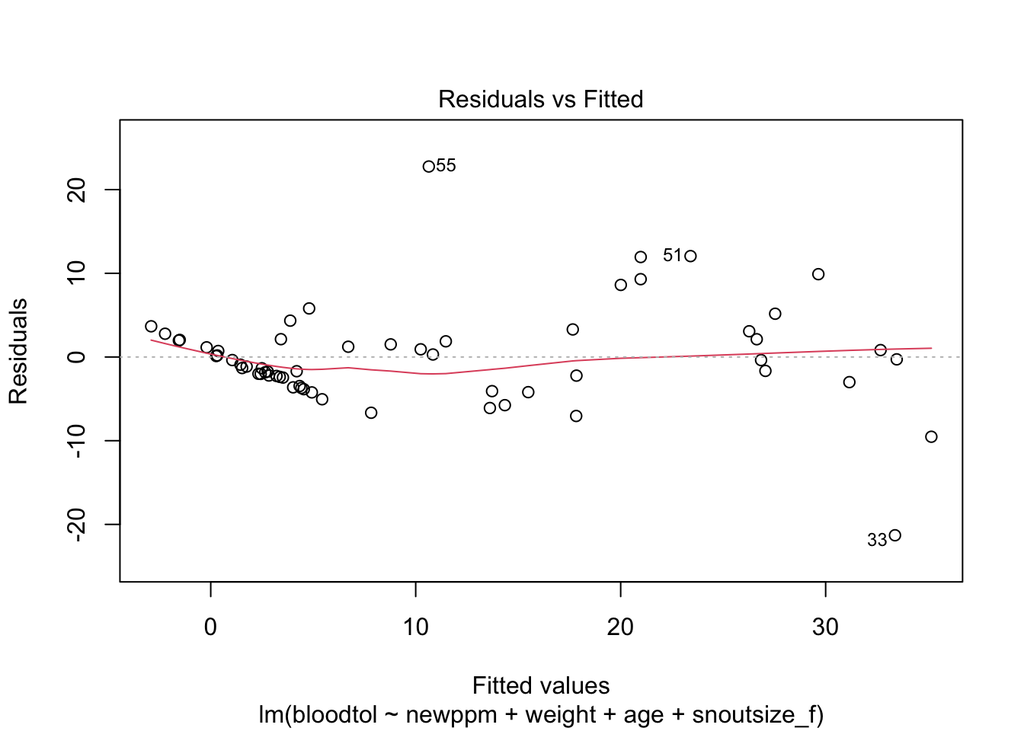

```r
# residual vs. fitted. values
resid_fitted <- plot(fit2, which=1)
```

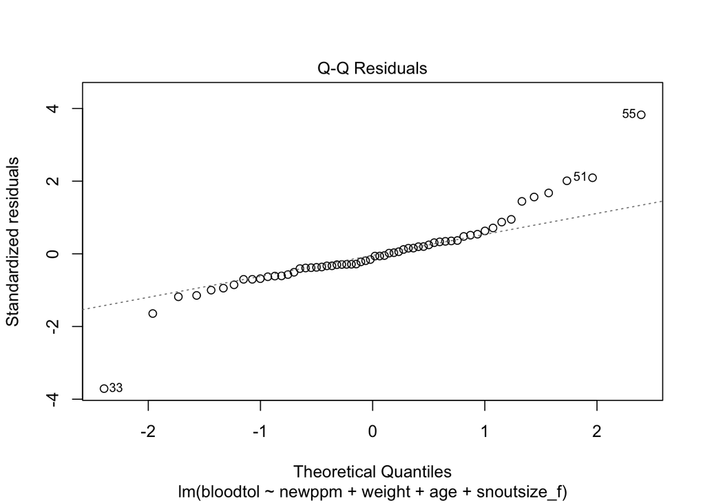

```r
# residual qq plot
resid_qq <- plot(fit2, which=2)
```

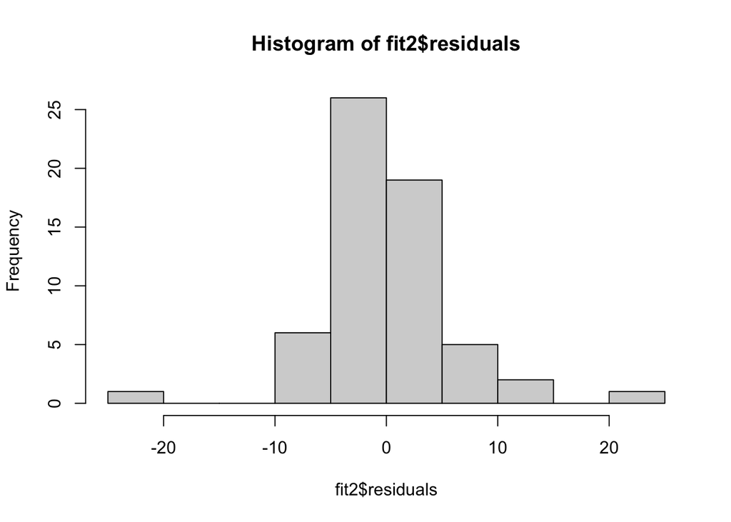

```r
# histogram of residuals
resid_hist <- hist(fit2$residuals)
```

**Comment:** I would choose a model including newppm, age, weight, and snout size as predictors. Even though weight and snout size were not statistically significant in the model, based on the background information and knowledge, all the covariates were considered to be important confounders, thus I determined to include all covariates. According to the residuals vs. fitted values plot, the linear regression and equal variance assumptions are met. However, according to the qq-plot, the distribution was not normal. Thus, normality assumption would be the most important thing to concern.

# Part 6) Identifying Influential or Outlier Points

**Identifying poorly fit, high leverage points, and/or influential points in the final model.**

```r
# the influence index plotting functions
hatvalues(fit2)
```

```
##          1          2          3          4          5          6          7
## 0.06661944 0.12486635 0.05851714 0.11757789 0.06556593 0.08883483 0.03639267
##          8          9         10         11         12         13         14
## 0.11737869 0.07902306 0.04724948 0.46325756 0.12056755 0.03490192 0.03930368
##         15         16         17         18         19         20         21
## 0.08861540 0.04218602 0.05201565 0.05365649 0.03786991 0.03688052 0.03345370
##         22         23         24         25         26         27         28
## 0.12049382 0.03597167 0.03310395 0.09945610 0.05674660 0.03555425 0.05622510
##         29         30         31         32         33         34         35
## 0.03361745 0.03990168 0.03150182 0.02613279 0.14259609 0.02378161 0.07033214
##         36         37         38         39         40         41         42
## 0.02308054 0.28647789 0.07485713 0.02797875 0.06874635 0.03266944 0.07512011
##         43         44         45         46         47         48         49
## 0.03637422 0.11620013 0.03231183 0.07962463 0.08106774 0.07350246 0.12660300
##         50         51         52         53         54         55         56
## 0.09795469 0.13757193 0.08929964 0.06512440 0.08563473 0.07937806 0.09201889
##         57         58         59         60
## 0.09062611 0.12573883 0.10787816 0.28401139
```

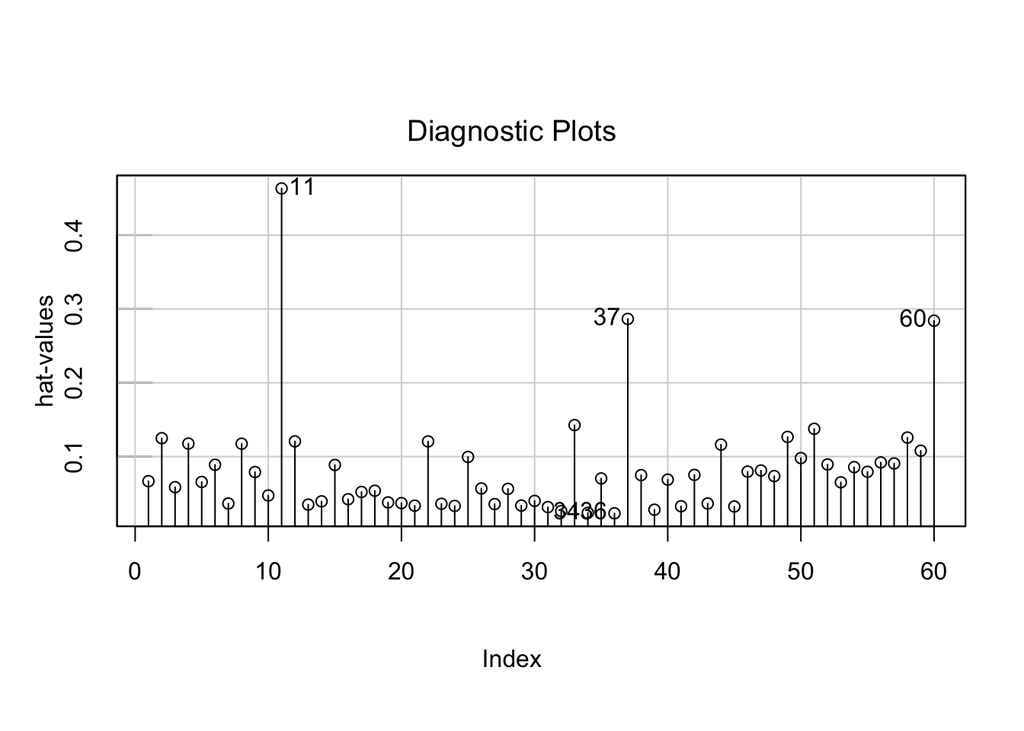

```r
influenceIndexPlot(fit2, "hat", id = list(n=5))
```

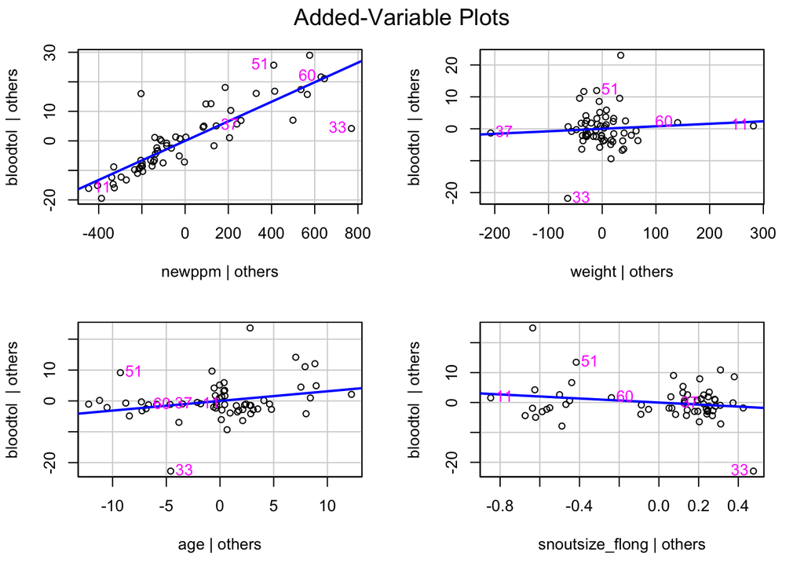

```r
avPlots(fit2, id=list(method=list(hatvalues(fit2)), n=5, cex=1, col=carPalette()[3], location="lr"))
```

```r
# average hat value
(length(fit2$coefficients))/nrow(fit2$model)
```

```
## [1] 0.08333333
```

```r
# 2(p+1)/n
thresh2 = 2*(length(fit2$coefficients))/nrow(fit2$model)
thresh2
```

```
## [1] 0.1666667
```

```r
# 3(p+1)/n
thresh3 = 3*(length(fit2$coefficients))/nrow(fit2$model)
thresh3
```

```
## [1] 0.25
```

```r
# point with leverage >3(p+1)/n
which(hatvalues(fit2)>thresh3) %>% unname()
```

```
## [1] 11 37 60
```

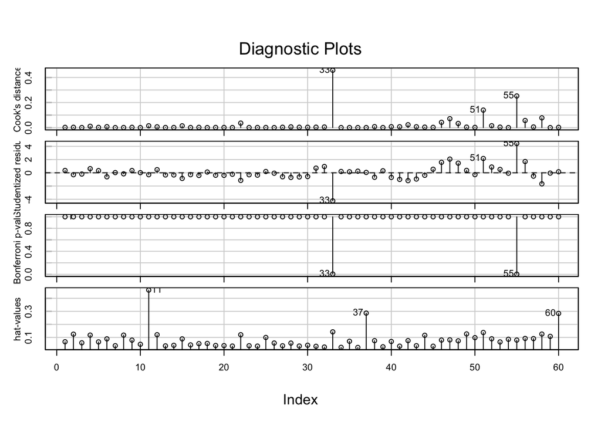

```r
influenceIndexPlot(fit2,id=list(n=3))
```

**Comment:** I chose points with leverage >3(p+1)/n. Points 11, 37, and 60 are high leverage based on hat-values.

# Part 7) Sensitivity to Outliers/Influential Points

**Performing a sensitivity analysis by refitting the model excluding the troublesome points in part 6.**

```r
# fit model removing outlier/influential points
fit5 <- lm(bloodtol ~ newppm + weight + age + snoutsize_f, data=toluene %>% slice(-c(11,37,60)))

# compare the two models
summary(fit5)
```

```
##
## Call:
## lm(formula = bloodtol ~ newppm + weight + age + snoutsize_f,
##     data = toluene %>% slice(-c(11, 37, 60)))
##
## Residuals:
##      Min       1Q   Median       3Q      Max
## -20.8910  -3.0587  -0.7485   2.0823  22.6546
##
## Coefficients:
##                   Estimate Std. Error t value Pr(>|t|)
## (Intercept)     -28.246371  17.722442  -1.594   0.1170
## newppm            0.032790   0.003005  10.911 4.69e-15 ***
## weight            0.016320   0.032972   0.495   0.6227
## age               0.317072   0.158437   2.001   0.0506 .
## snoutsize_flong  -3.939436   2.939214  -1.340   0.1860
## ---
## Signif. codes:  0 '***' 0.001 '**' 0.01 '*' 0.05 '.' 0.1 ' ' 1
##
## Residual standard error: 6.37 on 52 degrees of freedom
## Multiple R-squared:  0.7594, Adjusted R-squared:  0.7409
## F-statistic: 41.04 on 4 and 52 DF,  p-value: 1.696e-15
```

```r
#compare to original model
summary(fit2)
```

```
##
## Call:
## lm(formula = bloodtol ~ newppm + weight + age + snoutsize_f,
##     data = toluene)
##
## Residuals:
##      Min       1Q   Median       3Q      Max
## -21.2982  -2.5936  -0.6433   2.0629  22.7613
##
## Coefficients:
##                   Estimate Std. Error t value Pr(>|t|)
## (Intercept)     -25.190637  14.283095  -1.764   0.0833 .
## newppm            0.033114   0.002732  12.122   <2e-16 ***
## weight            0.007849   0.013948   0.563   0.5759
## age               0.312591   0.150875   2.072   0.0430 *
## snoutsize_flong  -3.397497   2.274375  -1.494   0.1409
## ---
## Signif. codes:  0 '***' 0.001 '**' 0.01 '*' 0.05 '.' 0.1 ' ' 1
##
## Residual standard error: 6.201 on 55 degrees of freedom
## Multiple R-squared:  0.7749, Adjusted R-squared:  0.7585
## F-statistic: 47.32 on 4 and 55 DF,  p-value: < 2.2e-16
```

**Comment:** The model was not sensitive to the troublesome points. There was no dramatic change in the coefficient estimates and statistical inference before and after excluding those points. The coefficient estimate of newppm was 0.033114 before exclusion, and 0.032790 after the exclusion.

# Part 8) Robust Regression

**Fitting a robust regression using the model from part 5 and compare the two models.**

```r
# fit robust regression model
fit2_robust <- rlm(bloodtol ~ newppm + weight + age + snoutsize_f, data=toluene)

summary(fit2_robust)
```

```
##
## Call: rlm(formula = bloodtol ~ newppm + weight + age + snoutsize_f,
##     data = toluene)
## Residuals:
##      Min       1Q   Median       3Q      Max
## -23.4522  -1.7244  -0.4215   1.8844  25.5379
##
## Coefficients:
##                 Value    Std. Error t value
## (Intercept)     -12.3493   8.1736    -1.5109
## newppm            0.0358   0.0016    22.8762
## weight           -0.0006   0.0080    -0.0775
## age               0.1561   0.0863     1.8079
## snoutsize_flong  -0.6022   1.3015    -0.4627
##
## Residual standard error: 2.578 on 55 degrees of freedom
```

```r
f.robftest(fit2_robust)
```

```
##
##  robust F-test (as if non-random weights)
##
## data:  from rlm(formula = bloodtol ~ newppm + weight + age + snoutsize_f, from     data = toluene)
## F = 134.62, p-value < 2.2e-16
## alternative hypothesis: two.sided
## null values:
##          newppm          weight             age snoutsize_flong
##               0               0               0               0
```

**Comment:** The coefficient estimate of newppm was larger in the robust model. it was 0.033114 in the original model and 0.0358 in the robust model. The F value was 47.32 in the original model while it was 134.62 in the robust model. According to the F test of robust regression model, the robust model showed better fit with higher F value. Considering the advantage of using robust model (less sensitive to outliers) and its better fit with higher F value, the robust model is more appropriate.

# Part 9) Summary

In this analysis, we examined association of toluene exposure with toluene concentration in the blood, adjusting for covariates including weight, age, and snout size. We found that after adjusting for potential confounders, there was a strong positive association between toluene exposure in ppm and toluene in blood (mg/L). Every 1 ppm increase in toluene exposure was associated with 0.033 increase in toluene concentration in the blood, holding all other variables constant. We did not find multicollinearity between the exposure, weight, age, or snout size. Our results changed slightly when outlier points were dropped in a sensitivity analysis. The association slightly attenuated but the strong association between toluene exposure and blood toluene concentration remained persistent. When robust model was used, 1-ppm increase in toluene exposure was associated with 0.036 increase in blood toluene. Thus, the strong positive association betwen toluene exposure and blood toluene concentration stayed valid in the robust model as well.